# Data Wrangling A2

## Transform

The histogram of confirmed cases is rightly skewed. Transforming the distribution might be done for better understanding.

Recommended transformation to correct for right skew include:  
Log transformation  
Natural log transformation  
Square root transformation  
Reciprocal transformation

In first data set, since most rows are excluded while merging (inner join) data sets, transformation wouldn’t affect the underlying structure of data. Out of all, log transformation values appear more closer to mean.

Since second dataset contains several negative GDP values, Normalization is not done.

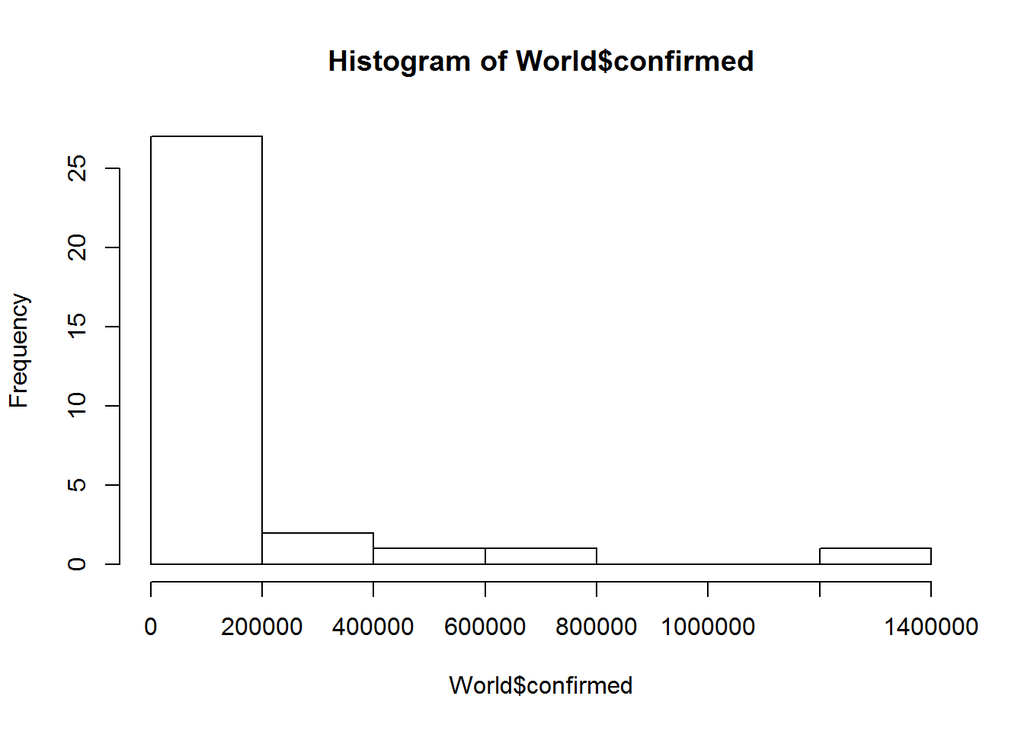

```r
# Normal histogram
hist(World$confirmed)
```

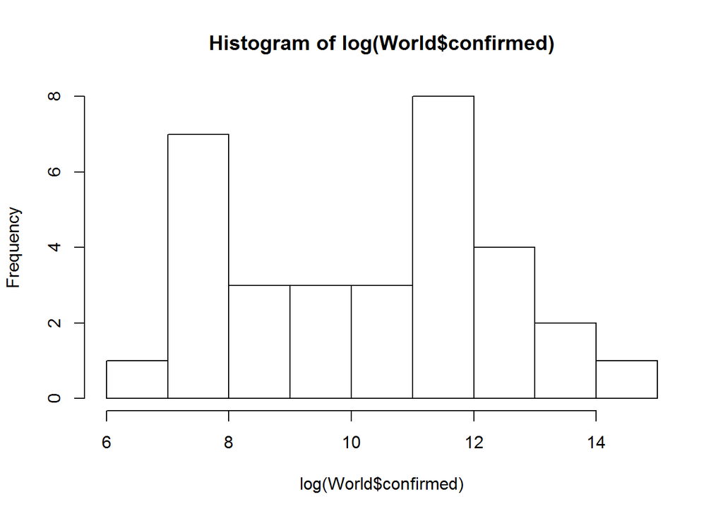

```r
# Using log transformation to check histogram for normalization.
# Since most rows are excluded transformation wouldn't affect the underlying structure

hist(log(World$confirmed))
```

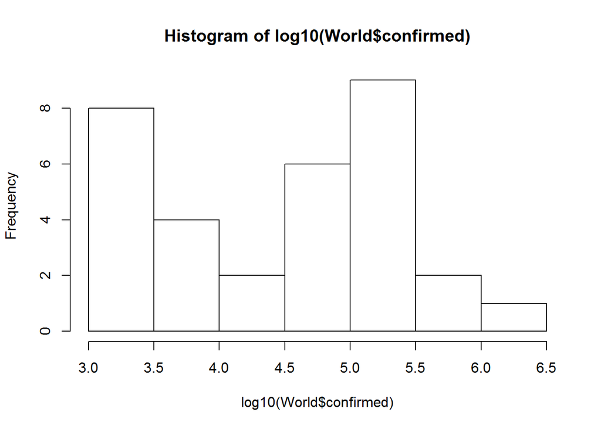

```r
hist(log10(World$confirmed))
```

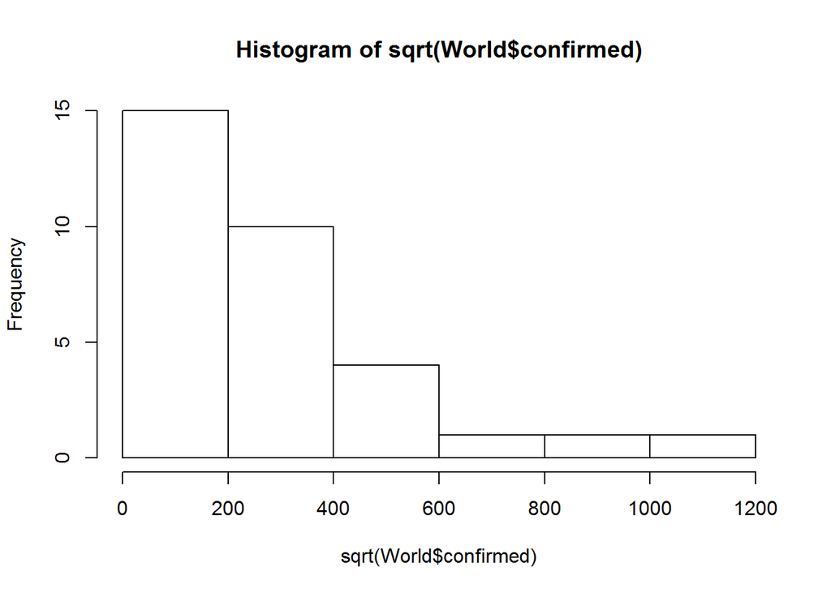

```r
hist(sqrt(World$confirmed))
```

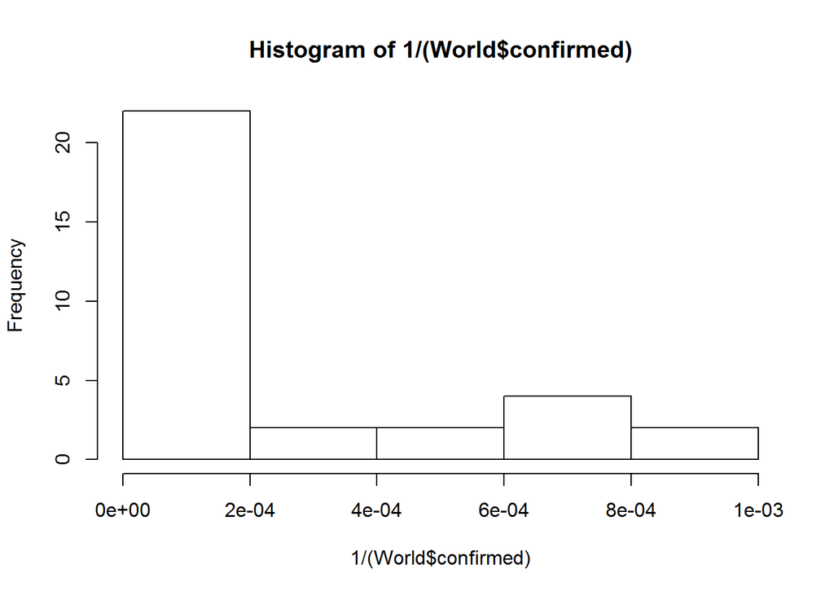

```r
hist(1/(World$confirmed))
```

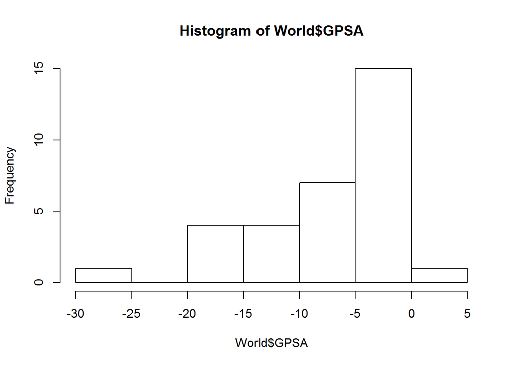

```r
# applying log transformation
World$confirmed <- log(World$confirmed)

# Normal histogram for measures. Normalization is not applied since it contains negative GDP values.
hist(World$GPSA)
```

## References

[1]“CSSEGISandData/COVID-19”, GitHub, 2020. [Online].  
Available: https://github.com/CSSEGISandData/COVID-19/tree/master/csse_covid_19_data/csse_covid_19_time_series.  
[Accessed: 20- Oct- 2020].

[2]“Quarterly National Accounts : G20 - Quarterly Growth Rates of GDP in volume”, Stats.oecd.org, 2020. [Online].  
Available: https://stats.oecd.org/index.aspx?queryid=33940.  
[Accessed: 20- Oct- 2020].